# Biostat M280 Homework 3

Due Mar 1 @ 11:59PM

Zanyu Shi UID: 805228169 zyshi@g.ucla.edu

## Q1 LA City Employee Payroll

1. For efficiency of the Shiny app, you should first pre-process, pare down, tidy, and save the data, e.g., as a compressed RDS file, to be used in the app.

```r
library(tidyverse)
library(data.table)
#read the .csv file
LACEP <- fread("/home/m280data/la_payroll/City_Employee_Payroll.csv")
LACEP = as.data.frame(LACEP)
names(LACEP) <- str_remove_all(names(LACEP), "[\\&\\(\\)]")
names(LACEP) <- str_replace_all(names(LACEP), " ", "_")
names(LACEP) <- str_replace_all(names(LACEP), "__", "_")
```

#### Save The dataset as a RDS file.

```r
saveRDS(LACEP,
      file = "/home/zyshi/biostat-m280-2019-winter/hw3/LACEP-app/LACEPdat.rds")
```

2. **Total payroll by LA City**. Visualize the total LA City payroll of each year, with breakdown into base pay, overtime pay, and other pay.
3. **Who earned most?** Visualize the payroll information (total payment with breakdown into base pay, overtime pay, and other pay, Department, Job Title) of the top $n$ highest paid LA City employees in a specific year. User specifies $n$ (default 10) and year (default 2017).
4. **Which departments earn most?** Visualize the mean or median payroll, with breakdown into base pay, overtime pay, and other pay, of top $n$ earning departments. User specifies $n$ (default 5), year (default 2017), and method (mean or median, default median).
5. **Which departments cost most?** Visualize the total payroll, with breakdown into base pay, overtime pay, and other pay, of top $n$ expensive departments. User specifies $n$ (default 5) and year (default 2017).
6. Visualize any other information you are interested in.
7. Publish your Shiny app to https://www.shinyapps.io and share the link.

### The link for my Shiny app:

My shiny app: https://zyshi-shinyapps.shinyapps.io/lacep-app/

## Q2 LA City Parking War

The SQLite database `/home/m280data/la_parking/LA_Parking_Citations.sqlite` on teaching server contains information about parking tickets in LA City. It was downloaded from [LA Open Data Portal](https://data.lacity.org/A-Well-Run-City/Parking-Citations/wjz9-h9np). Connect to the database and answer following questions using plots and summary statistics. In this exercise, you are **not** allowed to load whole data into memory. Use the *transform in database, plot in R* strategy.

#### Read the SQLite database

```r
library("DBI")
library("RSQLite")
library("dplyr")
db <- dbConnect(RSQLite::SQLite(),
        dbname = "/home/m280data/la_parking/LA_Parking_Citations.sqlite")
dbListTables(db)
```

```
## [1] "latix"
```

```r
lap_sql <- dplyr::tbl(db, "latix")
str(lap_sql)
```

[output not shown]

```r
lap_sql %>% print(width = Inf)
```

```
## # Source:   table<latix> [?? x 24]
## # Database: sqlite 3.22.0
## #   [/home/m280data/la_parking/LA_Parking_Citations.sqlite]
##    Ticket_number Issue_DateTime Issue_Year Issue_Month Issue_Day Issue_Hour
##            <dbl>          <dbl>      <int>       <int>     <int>      <int>
##  1    4272349605     1451512860       2015          12        30         22
##  2    4272349616     1451513100       2015          12        30         22
##  3    4272821512     1451496300       2015          12        30         17
##  4    4272821523     1451497080       2015          12        30         17
##  5    4272821534     1451498820       2015          12        30         18
##  6    4272889353     1451452440       2015          12        30          5
##  7    4274301964     1451909100       2016           1         4         12
##  8    1112509506     1450702500       2015          12        21         12
##  9    1112509510     1450703100       2015          12        21         13
## 10    1112509926     1450705200       2015          12        21         13
```

[output cut: 49 more lines]

1. How many tickets are in this data set? Which time period do these tickets span? Which years have most data?

### Solution

The number of tickets in this dataset is 7656418. The time period that these tickets span is from 01:00 07/02/2015 to 23:58 01/25/2019. The year 2017 has the most data.

```r
addr <- lap_sql %>%
  summarize(n = n()) %>%
  show_query()
```

```
## <SQL>
## SELECT COUNT() AS `n`
## FROM `latix`
```

```r
addr
```

```
## # Source:   lazy query [?? x 1]
## # Database: sqlite 3.22.0
## #   [/home/m280data/la_parking/LA_Parking_Citations.sqlite]
##         n
##     <int>
## 1 7656418
```

```r
tsyear <- lap_sql %>%
  filter(!is.na(Issue_Year), !is.na(Issue_Month),
         !is.na(Issue_Day), !is.na(Issue_Hour),
         !is.na(Issue_Minute), !is.na(Issue_Wday))

tsyear %>% arrange(desc(Issue_Year), desc(Issue_Month), desc(Issue_Day),
                 desc(Issue_Hour), desc(Issue_Minute)) %>%
  select(Issue_Year, Issue_Month, Issue_Day, Issue_Hour, Issue_Minute) %>%
  collect() %>%
  slice(c(1, n()))
```

```
## # A tibble: 2 x 5
##   Issue_Year Issue_Month Issue_Day Issue_Hour Issue_Minute
##        <int>       <int>     <int>      <int>        <int>
## 1       2019           1        25         23           58
## 2       2015           7         2          1            0
```

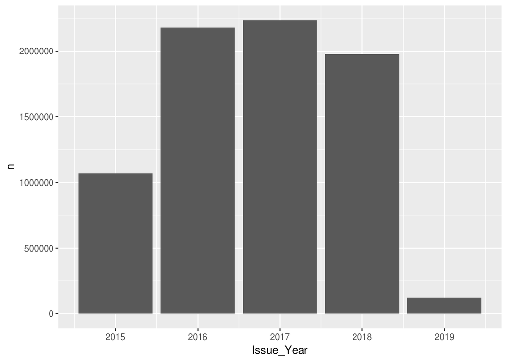

```r
lap_sql %>%
 group_by(Issue_Year) %>%
 count() %>%
 collect() %>%
 ggplot() +
 geom_col(aes(x = Issue_Year, y = n))
```

```r
thour <- lap_sql %>%
  group_by(Issue_Hour) %>%
  summarize(n = n()) %>%
  arrange(desc(n))
 thour
```

```
## # Source:     lazy query [?? x 2]
## # Database:   sqlite 3.22.0
## #   [/home/m280data/la_parking/LA_Parking_Citations.sqlite]
## # Ordered by: desc(n)
##    Issue_Hour      n
##         <int>  <int>
##  1         12 975063
##  2          8 960681
##  3         10 926833
##  4         11 659135
##  5          9 483991
##  6         13 475803
##  7         16 391378
##  8         14 358569
##  9         18 282714
## 10         17 278130
## # ... with more rows
```

#### b) Weekday:

```r
twday <- lap_sql %>%
  group_by(Issue_Wday) %>%
  summarize(n = n()) %>%
  arrange(desc(n))
 twday
```

```
## # Source:     lazy query [?? x 2]
## # Database:   sqlite 3.22.0
## #   [/home/m280data/la_parking/LA_Parking_Citations.sqlite]
## # Ordered by: desc(n)
##   Issue_Wday       n
##        <dbl>   <int>
## 1          3 1468900
## 2          5 1430433
## 3          4 1400552
## 4          6 1243156
## 5          2 1222875
## 6          7  446873
## 7          1  369564
## 8         NA   74065
```

#### c) Month day:

13th is the month day that you are most likely to get a ticket; 31st is the month day that you are least likely to get a ticket.

```r
tmday <- lap_sql %>%
  group_by(Issue_Day) %>%
  summarize(n = n()) %>%
  arrange(desc(n))
 tmday
```

```
## # Source:     lazy query [?? x 2]
## # Database:   sqlite 3.22.0
## #   [/home/m280data/la_parking/LA_Parking_Citations.sqlite]
## # Ordered by: desc(n)
##    Issue_Day      n
##        <int>  <int>
##  1        13 267419
##  2        20 260806
##  3        14 259383
##  4         8 257887
##  5         6 256905
##  6        21 256892
##  7        22 256758
##  8        17 254968
##  9         7 252678
## 10         3 252363
## # ... with more rows
```

#### d) Month:

August is the month that you are most likely to get a ticket; February is the month that you are least likely to get a ticket.

```r
tmonth <- lap_sql %>%
  group_by(Issue_Month) %>%
  summarize(n = n()) %>%
  arrange(desc(n))
 tmonth
```

```
## # Source:     lazy query [?? x 2]
## # Database:   sqlite 3.22.0
## #   [/home/m280data/la_parking/LA_Parking_Citations.sqlite]
## # Ordered by: desc(n)
##    Issue_Month      n
##          <int>  <int>
##  1           8 752904
##  2          10 708922
##  3          12 694987
##  4           7 681518
##  5           1 668404
##  6           9 663592
##  7          11 637852
##  8           3 595775
##  9           5 573197
## 10           4 553417
## # ... with more rows
```

3. Which car makes received most citations?

**The car make TOYT received the most citations.**

```r
 carm <- lap_sql %>%
   group_by(Make) %>%
   summarize(n = n()) %>%
   arrange(desc(n))
 carm
```

```
## # Source:     lazy query [?? x 2]
## # Database:   sqlite 3.22.0
## #   [/home/m280data/la_parking/LA_Parking_Citations.sqlite]
## # Ordered by: desc(n)
##    Make        n
##    <chr>   <int>
##  1 TOYT  1270804
##  2 HOND   865088
##  3 FORD   666786
##  4 NISS   552070
##  5 CHEV   519495
##  6 BMW    349172
##  7 MERZ   310812
##  8 VOLK   259663
##  9 HYUN   240399
## 10 DODG   225236
## # ... with more rows
```

4. How many different colors of cars were ticketed? Which color attracted most tickets?

**There are 103 different colors of cars ticketed; BK atrracted the most tickets 1652621.**

```r
 colorc <- lap_sql %>%
   group_by(Color) %>%
   summarize(n = n()) %>%
   arrange(desc(n))
colorc
```

```
## # Source:     lazy query [?? x 2]
## # Database:   sqlite 3.22.0
## #   [/home/m280data/la_parking/LA_Parking_Citations.sqlite]
## # Ordered by: desc(n)
##    Color       n
##    <chr>   <int>
##  1 BK    1652621
##  2 WT    1603566
##  3 GY    1497021
##  4 SL     953903
##  5 BL     591858
##  6 RD     378515
##  7 GN     213197
##  8 BN     148980
##  9 GO      97961
## 10 MR      91279
## # ... with more rows
```

5. What are the most common ticket types?

**“NO PARK/STREET CLEAN” is the most common ticket types.**

```r
typet <- lap_sql %>%
   group_by(Violation_Description) %>%
   summarize(n = n()) %>%
   arrange(desc(n))
typet
```

```
## # Source:     lazy query [?? x 2]
## # Database:   sqlite 3.22.0
## #   [/home/m280data/la_parking/LA_Parking_Citations.sqlite]
## # Ordered by: desc(n)
##    Violation_Description        n
##    <chr>                    <int>
##  1 NO PARK/STREET CLEAN   2234699
##  2 METER EXP.             1302155
##  3 RED ZONE                582135
##  4 PREFERENTIAL PARKING    523775
##  5 DISPLAY OF TABS         472750
##  6 NO PARKING              343489
##  7 DISPLAY OF PLATES       211693
##  8 WHITE ZONE              168596
##  9 PARKED OVER TIME LIMIT  156501
## 10 NO STOP/STANDING        138691
## # ... with more rows
```

6. How much money was collected on parking tickets in 2016, 2017 and 2018?

In 2016, 152145538 dollars are collected on parking tickets; in 2017, 157122489 dollars are collected on parking tickets; in 2018, 138875787 dollars are collected on parking tickets.

```r
mcpt <- lap_sql %>%
   group_by(Issue_Year) %>%
   summarize(moneyc = sum(Fine_amount))
mcpt
```

```
## # Source:   lazy query [?? x 2]
## # Database: sqlite 3.22.0
## #   [/home/m280data/la_parking/LA_Parking_Citations.sqlite]
##   Issue_Year    moneyc
##        <int>     <dbl>
## 1         NA   5137050
## 2       2015  75111152
## 3       2016 152145538
## 4       2017 157122489
## 5       2018 138875787
## 6       2019   8743347
```

7. If you’ve been ticketed in LA County, did you find your ticket in this data set?

Opps, I don’t have a car.

8. Read the blog http://www.brettrics.com/9-million-parking-tickets-la/ and try to reproduce plots using your data.

#### 1. Plot Top 10 Ticket Types by Top 10 Car Make:

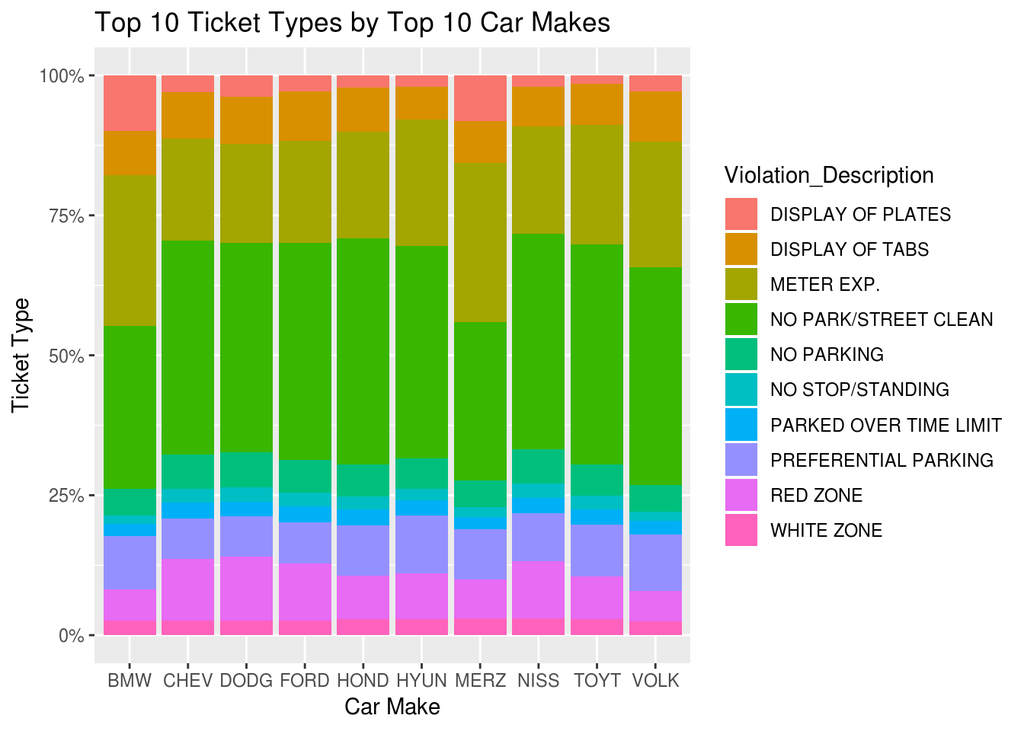

```r
library("ggplot2")
lap_sql %>%
 filter(!is.na(Make), !is.na(Violation_Description)) %>%
 filter(Make %in% c("TOYT", "HOND", "FORD", "NISS", "CHEV", "BMW", "MERZ",
                    "VOLK", "HYUN", "DODG")) %>%
 filter(Violation_Description %in% c("NO PARK/STREET CLEAN",    "METER EXP.",
      "RED ZONE",   "PREFERENTIAL PARKING", "DISPLAY OF TABS", "NO PARKING",
      "DISPLAY OF PLATES", "WHITE ZONE", "PARKED OVER TIME LIMIT",
      "NO STOP/STANDING"))  %>%
  ggplot(aes(Make, fill = Violation_Description)) +
  geom_bar(position = "fill") +
  labs(x="Car Make", y="Ticket Type",
       title="Top 10 Ticket Types by Top 10 Car Makes") +
   scale_y_continuous(labels=function(x) paste0(100*x,"%"))
```

#### 2. Plot the Number of Top 10 Ticket Types Per Day:

```r
dat <- lap_sql %>%
 filter(!is.na(Issue_Day), !is.na(Violation_Description)) %>%
 filter(Violation_Description %in% c("NO PARK/STREET CLEAN",    "METER EXP.",
      "RED ZONE",   "PREFERENTIAL PARKING", "DISPLAY OF TABS", "NO PARKING",
      "DISPLAY OF PLATES", "WHITE ZONE", "PARKED OVER TIME LIMIT",
      "NO STOP/STANDING"))  %>%
  group_by(Issue_Day, Violation_Description) %>%
  summarize(n = n()) %>%
  collect()
dat <- as.data.frame(dat)
```

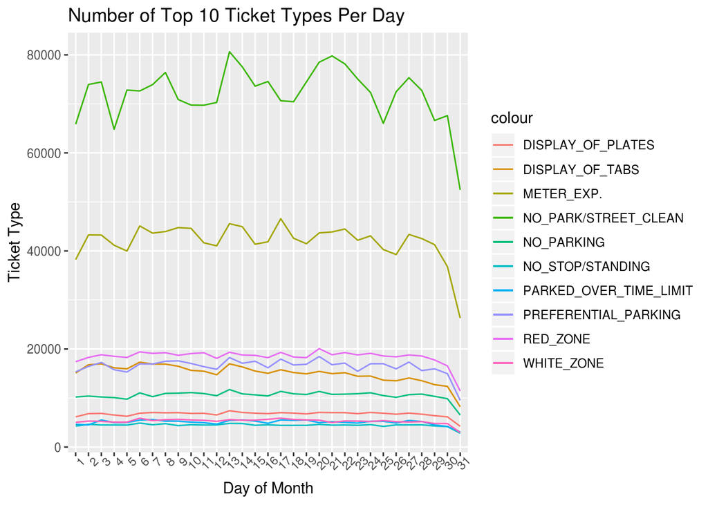

```r
dat1 <- spread(dat, key = Violation_Description, value = n)
names(dat1) <- str_replace_all(names(dat1), "/", " ")
names(dat1) <- str_replace_all(names(dat1), " ", "_")
library("ggplot2")
ggplot(dat1, aes(Issue_Day)) +
geom_line(aes(y = DISPLAY_OF_PLATES, colour = "DISPLAY_OF_PLATES")) +
geom_line(aes(y = DISPLAY_OF_TABS, colour = "DISPLAY_OF_TABS")) +
geom_line(aes(y = METER_EXP., colour = "METER_EXP.")) +
geom_line(aes(y = NO_PARK_STREET_CLEAN, colour = "NO_PARK/STREET_CLEAN")) +
geom_line(aes(y = NO_PARKING, colour = "NO_PARKING")) +
geom_line(aes(y = NO_STOP_STANDING, colour = "NO_STOP/STANDING")) +
geom_line(aes(y = PARKED_OVER_TIME_LIMIT, colour = "PARKED_OVER_TIME_LIMIT")) +
geom_line(aes(y = PREFERENTIAL_PARKING, colour = "PREFERENTIAL_PARKING")) +
geom_line(aes(y = RED_ZONE, colour = "RED_ZONE")) +
geom_line(aes(y = WHITE_ZONE, colour = "WHITE_ZONE")) +
labs(x="Day of Month", y="Ticket Type",
     title="Number of Top 10 Ticket Types Per Day") +
scale_x_discrete(limits=c(1:31)) +
theme(axis.text.x = element_text(angle=45))
```